# plotting samples (sites) and taxa (“species”) in vegan

jfg

16 May, 2022

## *`CCA`-veat emptor*

> **Note:** I had originally employed this in order to get NMDS or CCA to talk to `ggplot`. For PCoA, this could be viewed as contentious (**this could be wrong**), as we are essentially applying an *averaged linear* relationship to a dissimilarity space ( *bound 0-1*, ergo not exactly appropriate). See [the link](https://github.com/vegandevs/vegan/issues/438) and the help material for the relevant functions.

> However and ultimately, as an explorative method my hope is that the risk is low.

### 0/8 :: just the fracking code please

```r
    # well fine.
    # note these JTC chunks are usually not exactly the same as the embedded code

      library(vegan)
      library(ggplot2)


##  play_with_drugs dataset:  ========================================

    ## these are as shown above
      feat <- readRDS("../input/f/Julias_meds_presabs.RDS")
      mdat <- readRDS("../input/f/julias_meds_metadata.RDS")
      jc_dist <- readRDS("../input/f/julias_meds_jcd_dist.RDS")


## 1 :: calculate an ordination  ------------------------

      vegan_pcoa <- vegan::wcmdscale(jc_dist)

    # as wrapping cmdscale, this is a simple matrix:
      head( vegan_pcoa )


## 2 :: plot it ---------------------------------------

    # we can simply add on the data we need from mdat
      samp_ord <- rownames(vegan_pcoa)
      vpd <- as.data.frame(cbind( vegan_pcoa[ samp_ord, ],    # PCoA values
                                  mdat[ samp_ord, ]))         # metadata

    # could probably give better names to the PCoA axes
      colnames(vpd)[1:ncol(vegan_pcoa)] <- paste0( "axis_", 1:ncol(vegan_pcoa))
      head(vpd)

      (samp_plot <- ggplot( vpd, aes(x = axis_1, y = axis_2, fill = as.numeric(Age), shape = Disease)) +
          theme_minimal() +
          coord_fixed(ratio =  1, ylim = c(-0.5,0.5), xlim = c(-0.5,0.5) ) +
          geom_point(size = 4) +
          scale_shape_manual(values=  c(21,22)) +
          labs(
            title="a simple vegan PCoA in ggplot",
            subtitle = "compare with the first plot above",
            y = "PC2 - second strongest trend",
            x = "PC1 - strongest trend",
            caption = "huzzah"
          ))


## 3  get med scores --------------------------------

    # no species scores available - samples only (these are all the same)
      all( as.list(
        (vegan_pcoa) == scores(vegan_pcoa),
        scores(vegan_pcoa) == scores(vegan_pcoa, display = "sites"),
        scores(vegan_pcoa) == scores(vegan_pcoa, display = "species")
      ))

    # need to make new scores for these data: go via
      vegan_pcoa_feats <- as.data.frame(wascores(x = vegan_pcoa, w = feat))

    # adding on data maxes less sense here, but some hierarchy data about meds would fit nicely
      vp_feats <- vegan_pcoa_feats
      vp_feats$rubbish <- rep(c("A", "B"), 5)
      vp_feats$med <- rownames(vp_feats)

    # could probably give better names to the PCoA axes
      colnames(vp_feats)[1:ncol(vegan_pcoa_feats)] <- paste0( "axis_", 1:ncol(vegan_pcoa_feats))


## 4  plot med scores --------------------------------

      (feat_plot <- ggplot( vp_feats, aes(x = axis_1, y = axis_2, fill = rubbish, colour = rubbish)) +
          coord_fixed(ratio =  1, ylim = c(-0.5,0.5), xlim = c(-0.5,0.5) ) +
          theme_minimal() +
          geom_text(aes(label = med), size = 4) +
          scale_shape_manual(values=  c(21,22)) +
          labs(
            title="abundance-weighted positions",
            subtitle = "of meds to sample location",
            y = "PC2 - second strongest trend",
            x = "PC1 - strongest trend",
            caption = "hurrmm."
          ))


    ## check again
      # head(vpd)
      # head(vp_feats)

    # biplot med and sample scores
      ggplot( vpd ) +
        theme_minimal() +
        coord_fixed(ratio =  1, ylim = c(-0.5,0.5), xlim = c(-0.5,0.5) ) +
        # samples
        geom_point( aes(x = axis_1, y = axis_2, fill = as.numeric(Age), shape = Disease), size = 4) +
        # text
        geom_text(data = vp_feats, aes(x = axis_1, y = axis_2, label = med, colour = rubbish), size = 4) +
        scale_shape_manual(values=  c(21,22)) +
        labs(
          title="abundance-weighted positions",
          subtitle = "of meds to sample location",
          y = "PC2 - second strongest trend",
          x = "PC1 - strongest trend",
          caption = "hurrmm."
        )
```

## skippable preamble - “species” in ordinations

### 1/8 :: introduction

Multivariate ordination methods make us feel good about ourselves while allowing us to mathematically relate, and then visualise, many (many..) samples from a dataset. Many popular methods will use the feature table (e.g. `samples * features`) to create a distance matrix of how similar samples are to one another, giving us a table that tells a lot about relatedness of `samples` but has ‘used up’ all of the `feature` information to do so - these distance matrices tell us nothing about the `features` themselves.

For instance, the following tables show the first 5 samples in our `play_with_drugs` dataset; firstly relating the medications taken:

|  | A07EC02 | Resection | A11CC | A11A | A12AA | N02BA01 | B03BA | L04AX01 | C10AX06 | N02BE01 |
| --- | --- | --- | --- | --- | --- | --- | --- | --- | --- | --- |
| S198.2 | 0 | 1 | 1 | 1 | 1 | 1 | 0 | 0 | 1 | 0 |
| S126.1.2 | 1 | 1 | 1 | 1 | 1 | 1 | 0 | 0 | 1 | 0 |
| S162.2 | 0 | 1 | 1 | 0 | 1 | 1 | 0 | 0 | 1 | 0 |
| S74.3 | 0 | 0 | 0 | 0 | 1 | 1 | 0 | 0 | 0 | 0 |
| S226.2 | 0 | 0 | 1 | 1 | 1 | 0 | 0 | 0 | 0 | 0 |

as well as environmental factors or variables that characterise the human people who are our ‘observations’ or ‘samples’:

|  | Disease | Patient | Age |
| --- | --- | --- | --- |
| S198.2 | CD | M2748 | 76 |
| S126.1.2 | CD | M2748 | 76 |
| S162.2 | CD | M2748 | 76 |
| S74.3 | UC | M5485 | 86 |
| S226.2 | UC | M1388 | 66 |

We can understand how `samples` (people) are affected by medications and environmental factors in the `play_with_drugs` dataset by working out what samples are the most similar to each other, and trying to relate this to the nature of the dataset we have. To do this, we’ve calculated the *Jaccardian* dissimilarities (a presence / absence metric; mathematics not important here) between those samples, where:

- samples with the exact same pattern of medications (i.e. identical samples) will have a dissimilarity value of `0` to each other.
- samples which are totally unalike will have a maximal value of `1` with respect to each other, indicating they are as unalike as is possible.
- samples in between identical and unalike (i.e. most samples) will be related by values ranging from `0` to `1`, depending on how alike or unalike they are.

The start of the table of these dissimilarities is below. Note there are no medications: medication presence/absences were smelted down during the *calculation*, and the info output from that calculation tells us about the *samples only*: so we have samples on the rows and columns:

|  | S198.2 | S126.1.2 | S162.2 | S74.3 | S226.2 |
| --- | --- | --- | --- | --- | --- |
| S198.2 | 0.0000000 | 0.1428571 | 0.1666667 | 0.6666667 | 0.5000000 |
| S126.1.2 | 0.1428571 | 0.0000000 | 0.2857143 | 0.7142857 | 0.5714286 |
| S162.2 | 0.1666667 | 0.2857143 | 0.0000000 | 0.6000000 | 0.6666667 |
| S74.3 | 0.6666667 | 0.7142857 | 0.6000000 | 0.0000000 | 0.7500000 |
| S226.2 | 0.5000000 | 0.5714286 | 0.6666667 | 0.7500000 | 0.0000000 |

We can now represent how similar these samples are using a multivariate ordination method (there are *many*) to break down all these different interactions such that **(a)** we see the most strongest effects first, and **(b)** we can happily visualise these trends in ways that are somewhat sensible.

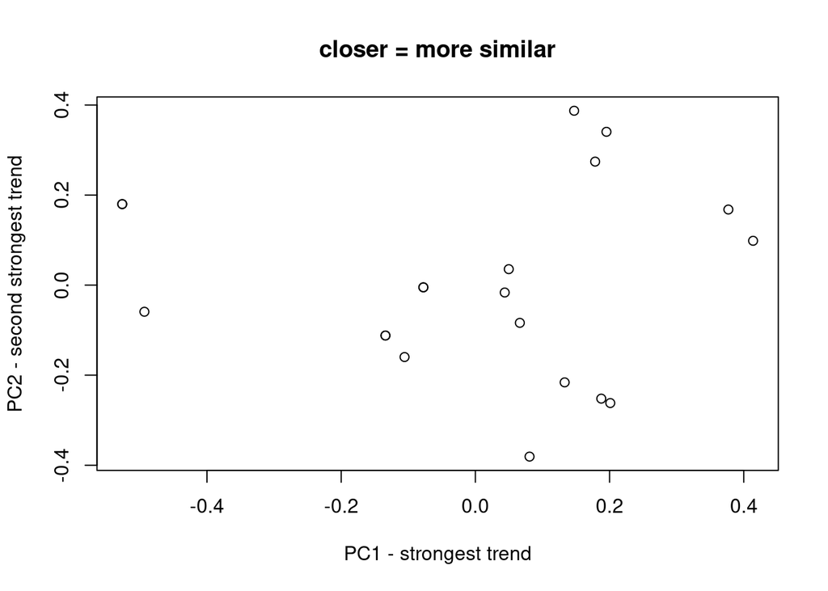

### 2/8 :: intent

That should all make sense so far. However, our goal here is to find way to reveal (or create), and plot the corresponding pattern of feature abundances in the same reference frame, that is

- **plot features as well as samples**

Note that those features can be taxa, ASV, genes, etc., - in `play_with_drugs`, each feature tells us whether or not a sample (human person) has taken that medication, in presence absence (`0` of `1`)/ format.

Here we’re using `vegan`’s machinery rather than `ape`. `Ape`’s `pcoa` is *functionally* equivalent to `vegan`’s `wcmdscale`, (which wraps and can weight `stats::cmdscale` - classic multidimensional scaling is simply another (older?) name for PCoA).

Here, we’ll use `vegan` to:

1. **calculate an ordination** : in `vegan`, make a PCoA of some reduced `sample*medication` data, see how features (i.e. medication) fit into this, and maybe add some environmental variables as relevant.
2. **plotting that ordination** : getting the `df` pieces we need to plot the relationship between samples
3. **extract species scores** : retrieve from the ordination object `vegan` gives us in `1` above, or calculate from our dissimilarity data and species abundances.
4. **plot species scores** too, getting the bits we need as we need them.

These data (sites / samples) can then be plotted in the usual fashion, or made to look all faaaancy in `ggplot`. Checking base is usually a handy reference to make sure that outputs match, but for plotting shenanigans we’ll be using `ggplot2` instead.

**NB:** the package `ggvegan` was built to do all of this for you. Nevertheless.

## actual workings

### 3/8 :: invoke

Open books, dust off books:

```r
  library(vegan)
  library(ggplot2)
```

### 4/8 :: ingest

Suck data in through a straw:

```r
  ## play_with_drugs dataset:  ========================================

  ## these are as shown above
    feat <- readRDS("../input/f/Julias_meds_presabs.RDS")
    mdat <- readRDS("../input/f/julias_meds_metadata.RDS")
    jc_dist <- readRDS("../input/f/julias_meds_jcd_dist.RDS")
```

### 5/8 :: inspect

We can quickly make an ordination obejct in vegan, view it’s output (**1.** above; this is the actual result), and then plot that output (**2.** above; but remember this is just a communication tool, whether to yourself or whoever).

Recently, I’ve gotten quite attached to using non-metric multidimensional scaling (NMDS), a successor to the PCoA method that uses random starting points to create more robust outcomes in it’s calculation - and in `vegan`, it also retains info about features (assuming you provide features to the function). By default, it will condense things down to 2 axes (imagine *that*) as best it can, but this can be changed using `k`.

```r
  # provide features and specify distance (dissim) metric
  # from above, we know that SAMPLES ARE ROWS, which is the format vegan uses
    vegan_nmds <- metaMDS( comm = feat, distance = "jaccard")
## Run 0 stress 0.1311562
## Run 1 stress 0.1313436
## ... Procrustes: rmse 0.07457242  max resid 0.293223
## Run 2 stress 0.1535708
## Run 3 stress 0.1661396
## Run 4 stress 0.1311562
## ... New best solution
## ... Procrustes: rmse 3.499105e-05  max resid 8.143642e-05
## ... Similar to previous best
## Run 5 stress 0.1516419
## Run 6 stress 0.1313436
## ... Procrustes: rmse 0.07455484  max resid 0.293168
## Run 7 stress 0.1311562
## ... Procrustes: rmse 1.024811e-05  max resid 1.71445e-05
## ... Similar to previous best
## Run 8 stress 0.1311562
## ... Procrustes: rmse 0.0001681527  max resid 0.0003135706
## ... Similar to previous best
## Run 9 stress 0.1311563
## ... Procrustes: rmse 9.690487e-05  max resid 0.0001671133
## ... Similar to previous best
## Run 10 stress 0.1311564
## ... Procrustes: rmse 0.0001622577  max resid 0.0003102372
## ... Similar to previous best
## Run 11 stress 0.1311562
## ... Procrustes: rmse 1.109401e-05  max resid 2.761547e-05
## ... Similar to previous best
## Run 12 stress 0.1311562
## ... Procrustes: rmse 1.955038e-05  max resid 3.630332e-05
## ... Similar to previous best
## Run 13 stress 0.1311562
## ... New best solution
## ... Procrustes: rmse 8.019582e-05  max resid 0.000151787
## ... Similar to previous best
## Run 14 stress 0.1747967
## Run 15 stress 0.1516419
## Run 16 stress 0.1516419
## Run 17 stress 0.1311563
## ... Procrustes: rmse 0.0001709684  max resid 0.0003668555
## ... Similar to previous best
## Run 18 stress 0.1711124
## Run 19 stress 0.1313437
## ... Procrustes: rmse 0.07456193  max resid 0.2930879
## Run 20 stress 0.1311562
## ... New best solution
## ... Procrustes: rmse 1.828007e-05  max resid 3.175195e-05
## ... Similar to previous best
## *** Solution reached

  # come see
    vegan_nmds
##
## Call:
## metaMDS(comm = feat, distance = "jaccard")
##
## global Multidimensional Scaling using monoMDS
##
## Data:     feat
## Distance: jaccard
##
## Dimensions: 2
## Stress:     0.1311562
## Stress type 1, weak ties
## Two convergent solutions found after 20 tries
## Scaling: centring, PC rotation, halfchange scaling
## Species: expanded scores based on 'feat'
```

Note that a default plot will include both the samples and features - something that was not the case in the PCoA (`wcmdscale`) plot at the top of the page:

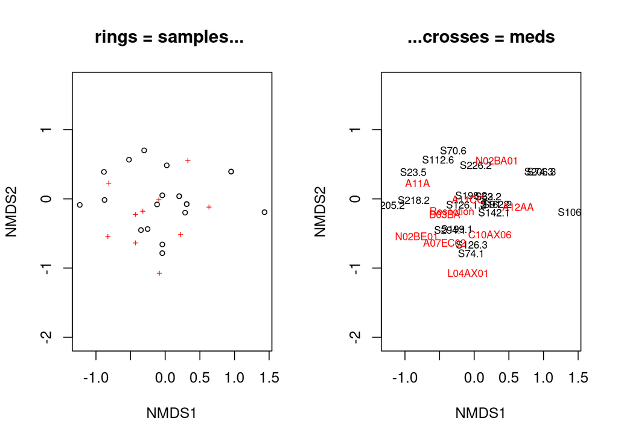

```r
    par(mfrow = c(1,2))
    plot(vegan_nmds, main = "rings = samples... ")
    plot(vegan_nmds, main = "...crosses = meds", type = "text")
```

Note also how visible the “`species`” data is: `vegan_nmds$species`. However, the developers specifically warn us to not access this data directly, and to **use the `scores` function** they have created expressly for this purpose:

```r
  # this is the correct way to access this data
    lapply( scores( vegan_nmds ), head)
## $sites
##                NMDS1       NMDS2
## S198.2   -0.04248111  0.05090847
## S126.1.2 -0.11775709 -0.08050481
## S162.2    0.31010222 -0.07546734
## S74.3     0.95142433  0.39398828
## S226.2    0.02223014  0.48415585
## S74.1    -0.04255766 -0.78447867
##
## $species
##                 NMDS1       NMDS2
## A07EC02   -0.43221534 -0.63560654
## Resection -0.32664154 -0.17856929
## A11CC     -0.08922403 -0.01264279
## A11A      -0.81546831  0.22908868
## A12AA      0.63400176 -0.11633831
## N02BA01    0.32625626  0.55270453

  # note alos also - only shows scores for species
```

#### interjection: most vegan analyses are similarly structured

If curious, (Constrained) Correspondence Analysis does something similar, but using `ChiSq` distances between both samples and “species” rather than a dissimilarity: consider checking this out, and seeing the slightly different structure to the scores object contained within the output. Code `NOTRUN`.

```r
    # again, many options, but we require at least a feature table, metadata, and formula
    # here, we specify to include everything (1) in the calculation
      vegan_cca <- cca( feat ~ 1, data = mdat)

    # come see
      vegan_cca

    # again, structure to explore - consider using View in Rstudio
      str( vegan_cca )

    # finally, a different sort of scores for CCA:
      scores(vegan_cca)

    # plot with similar conventions to those above.
      plot(vegan_cca)
```

### 6/8 :: interpret

There are all sorts of terrible (in the sense of “instilling terror”) things you could do with your plots. We are going to sidestep all of that and make a very simple PCoA using `vegan` and `ggplot`. It will take at least as long to do it this way, but it fits better with the way we live now.

For this first part we’ll:

1. calculate an ordination
2. plotting that ordination in `ggplot2`

```r
## 1 :: calculate an ordination  ------------------------

      vegan_pcoa <- vegan::wcmdscale(jc_dist)

    # as wrapping cmdscale, this is a simple matrix:
      head( vegan_pcoa )
```

```
##                 [,1]        [,2]        [,3]        [,4]        [,5]        [,6]         [,7]
## S198.2    0.04376255 -0.01641728 -0.13641461  0.13557586 -0.03741459 -0.08176176 -0.146890139
## S126.1.2  0.06628774 -0.08379026 -0.10397026  0.15595034 -0.11160751 -0.02861629 -0.122439725
## S162.2   -0.13400664 -0.11196259 -0.26126556  0.08166684 -0.01437281 -0.11336526 -0.077347020
## S74.3    -0.52627720  0.17990727  0.03594387 -0.02845825 -0.05018971  0.07107306  0.002455035
## S226.2    0.04979597  0.03545095  0.33368000  0.25229070  0.10049321 -0.09167618  0.020930186
## S74.1     0.08074257 -0.38082491 -0.06893827 -0.18830137  0.09597969  0.11135290 -0.081485094
##                 [,8]         [,9]        [,10]
## S198.2    0.01304695  0.038518532  0.019095043
## S126.1.2  0.18969951 -0.059354180 -0.009302217
## S162.2   -0.03055010  0.002762573 -0.005028016
## S74.3     0.03377871  0.024798996  0.002017258
## S226.2   -0.06260614 -0.050810604  0.015248491
## S74.1    -0.14189139 -0.026776884 -0.005229956
```

```r
## 2 :: plot it ---------------------------------------

    # we can simply add on the data we need from mdat
      samp_ord <- rownames(vegan_pcoa)
      vpd <- as.data.frame(cbind( vegan_pcoa[ samp_ord, ],    # PCoA values
                                  mdat[ samp_ord, ]))         # metadata

    # could probably give better names to the PCoA axes
      colnames(vpd)[1:ncol(vegan_pcoa)] <- paste0( "axis_", 1:ncol(vegan_pcoa))
      head(vpd)
```

```
##               axis_1      axis_2      axis_3      axis_4      axis_5      axis_6       axis_7
## S198.2    0.04376255 -0.01641728 -0.13641461  0.13557586 -0.03741459 -0.08176176 -0.146890139
## S126.1.2  0.06628774 -0.08379026 -0.10397026  0.15595034 -0.11160751 -0.02861629 -0.122439725
## S162.2   -0.13400664 -0.11196259 -0.26126556  0.08166684 -0.01437281 -0.11336526 -0.077347020
## S74.3    -0.52627720  0.17990727  0.03594387 -0.02845825 -0.05018971  0.07107306  0.002455035
## S226.2    0.04979597  0.03545095  0.33368000  0.25229070  0.10049321 -0.09167618  0.020930186
## S74.1     0.08074257 -0.38082491 -0.06893827 -0.18830137  0.09597969  0.11135290 -0.081485094
##               axis_8       axis_9      axis_10 Disease Patient Age
## S198.2    0.01304695  0.038518532  0.019095043      CD   M2748  76
## S126.1.2  0.18969951 -0.059354180 -0.009302217      CD   M2748  76
## S162.2   -0.03055010  0.002762573 -0.005028016      CD   M2748  76
## S74.3     0.03377871  0.024798996  0.002017258      UC   M5485  86
## S226.2   -0.06260614 -0.050810604  0.015248491      UC   M1388  66
## S74.1    -0.14189139 -0.026776884 -0.005229956      CD    M205  55
```

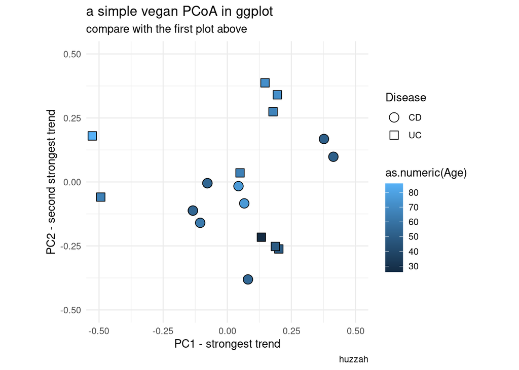

```r
      (samp_plot <- ggplot( vpd, aes(x = axis_1, y = axis_2, fill = as.numeric(Age), shape = Disease)) +
        theme_minimal() +
        coord_fixed(ratio =  1, ylim = c(-0.5,0.5), xlim = c(-0.5,0.5) ) +
        geom_point(size = 4) +
        scale_shape_manual(values=  c(21,22)) +
        labs(
          title="a simple vegan PCoA in ggplot",
          subtitle = "compare with the first plot above",
          y = "PC2 - second strongest trend",
          x = "PC1 - strongest trend",
          caption = "huzzah"
        ))
```

### 7/8 :: interpolate

Now: the only bit of info you actually asked for - *how the species*. Tasks:

3. extract species scores
4. plot species scores too.

We find that because the PCoA object never *saw* species data, there is none to extract. So, we *make* new species scores for, or with reference to, the PCOA object. Specifically for PCoA (`wcmdscale`) we are required to make weighted averages of the features’ position in the plot using `wascores`.

**See also the caveat at opening.**

```r
## 3  get med scores --------------------------------

  # no species scores available - samples only (these are all the same)
      all( as.list(
        (vegan_pcoa) == scores(vegan_pcoa),
        scores(vegan_pcoa) == scores(vegan_pcoa, display = "sites"),
        scores(vegan_pcoa) == scores(vegan_pcoa, display = "species")
      ))
```

```
## [1] TRUE
```

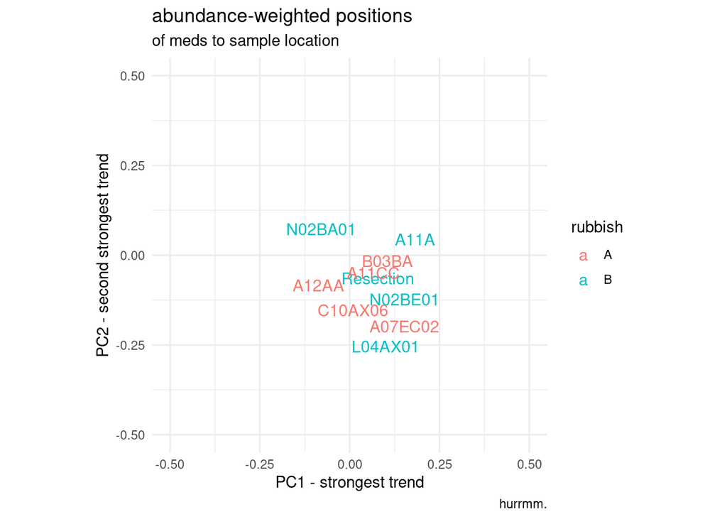

```r
  # need to make new scores for these data: go via
    vegan_pcoa_feats <- as.data.frame(wascores(x = vegan_pcoa, w = feat))

  # adding on data maxes less sense here, but some hierarchy data about meds would fit nicely
    vp_feats <- vegan_pcoa_feats
    vp_feats$rubbish <- rep(c("A", "B"), 5)
    vp_feats$med <- rownames(vp_feats)

  # could probably give better names to the PCoA axes
    colnames(vp_feats)[1:ncol(vegan_pcoa_feats)] <- paste0( "axis_", 1:ncol(vegan_pcoa_feats))


## 4  plot med scores --------------------------------

    (feat_plot <- ggplot( vp_feats, aes(x = axis_1, y = axis_2, fill = rubbish, colour = rubbish)) +
      coord_fixed(ratio =  1, ylim = c(-0.5,0.5), xlim = c(-0.5,0.5) ) +
      theme_minimal() +
      geom_text(aes(label = med), size = 4) +
      scale_shape_manual(values=  c(21,22)) +
      labs(
        title="abundance-weighted positions",
        subtitle = "of meds to sample location",
        y = "PC2 - second strongest trend",
        x = "PC1 - strongest trend",
        caption = "hurrmm."
      ))
```

(These methods have been simplified recently)[https://github.com/vegandevs/vegan/issues/438], but do not yet seem to be available (see below)

```r
   # :(  why jari why
    sppscores(vegan_pcoa)
    # > Error: 'sppscores' is not implemented yet
```

### 8/8 :: incorporate

No harm in presenting them together. There are more elaborate ways and we should all feel free to explore them.

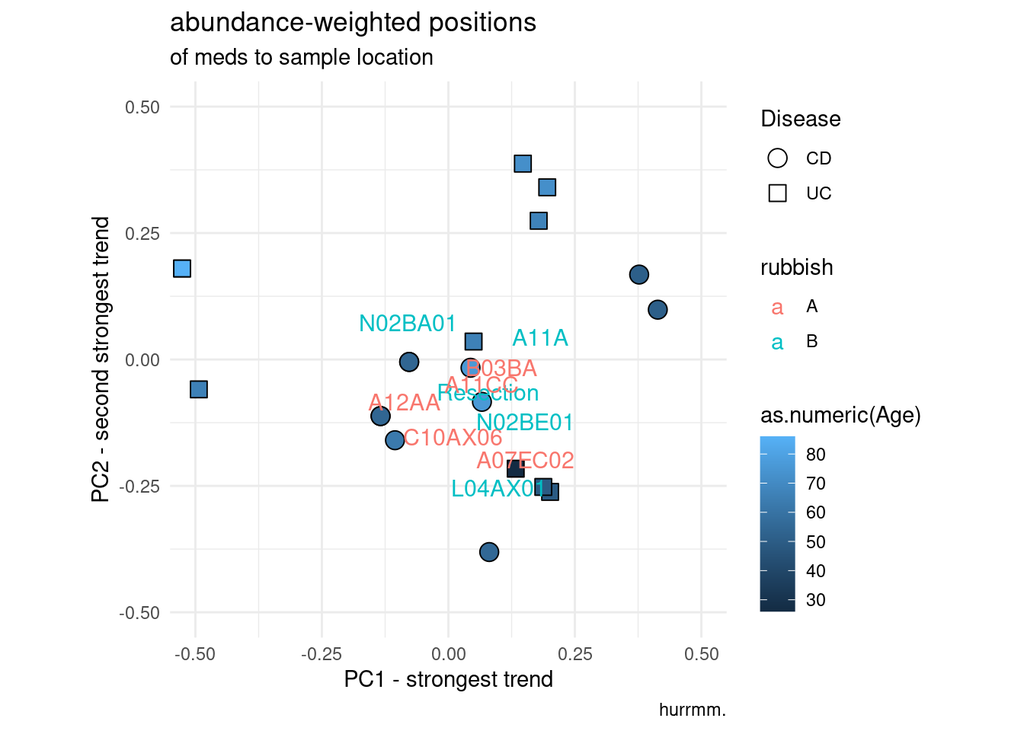

```r
    # what we got
      head(vpd)
##               axis_1      axis_2      axis_3      axis_4      axis_5      axis_6       axis_7
## S198.2    0.04376255 -0.01641728 -0.13641461  0.13557586 -0.03741459 -0.08176176 -0.146890139
## S126.1.2  0.06628774 -0.08379026 -0.10397026  0.15595034 -0.11160751 -0.02861629 -0.122439725
## S162.2   -0.13400664 -0.11196259 -0.26126556  0.08166684 -0.01437281 -0.11336526 -0.077347020
## S74.3    -0.52627720  0.17990727  0.03594387 -0.02845825 -0.05018971  0.07107306  0.002455035
## S226.2    0.04979597  0.03545095  0.33368000  0.25229070  0.10049321 -0.09167618  0.020930186
## S74.1     0.08074257 -0.38082491 -0.06893827 -0.18830137  0.09597969  0.11135290 -0.081485094
##               axis_8       axis_9      axis_10 Disease Patient Age
## S198.2    0.01304695  0.038518532  0.019095043      CD   M2748  76
## S126.1.2  0.18969951 -0.059354180 -0.009302217      CD   M2748  76
## S162.2   -0.03055010  0.002762573 -0.005028016      CD   M2748  76
## S74.3     0.03377871  0.024798996  0.002017258      UC   M5485  86
## S226.2   -0.06260614 -0.050810604  0.015248491      UC   M1388  66
## S74.1    -0.14189139 -0.026776884 -0.005229956      CD    M205  55
      head(vp_feats)
##                axis_1      axis_2       axis_3      axis_4       axis_5        axis_6        axis_7
## A07EC02    0.15166220 -0.19926106  0.073428718  0.08365521 -0.150179156  0.0558659705  0.0248471589
## Resection  0.07849010 -0.06521975 -0.073612371 -0.03054566 -0.045572508 -0.0221959427  0.0094333902
## A11CC      0.06601668 -0.04952126 -0.036800930  0.05256886  0.028160696 -0.0003320563  0.0112779313
## A11A       0.18123718  0.04305283  0.058906059  0.03821804 -0.016666439  0.0122227053 -0.0198982774
## A12AA     -0.08746657 -0.08455403 -0.005325622  0.01721738  0.006398736 -0.0002727897  0.0008189123
## N02BA01   -0.07916566  0.07234730 -0.113609317  0.02291441 -0.009008736  0.0106884649  0.0001927133
##                 axis_8        axis_9       axis_10 rubbish       med
## A07EC02    0.108901816 -0.0304958988 -2.596345e-03       A   A07EC02
## Resection  0.004219784 -0.0019670471  3.825382e-04       B Resection
## A11CC     -0.002891006 -0.0046472594 -2.013266e-05       A     A11CC
## A11A       0.016514729  0.0009370055  9.612696e-04       B      A11A
## A12AA      0.007142294 -0.0024358349  1.095235e-03       A     A12AA
## N02BA01    0.008129761 -0.0014519796  3.183461e-04       B   N02BA01

    # what we plot - beware the balance here of whats plotted for meds/samples
      ggplot( vpd ) +
          theme_minimal() +
          coord_fixed(ratio =  1, ylim = c(-0.5,0.5), xlim = c(-0.5,0.5) ) +
          # samples
          geom_point( aes(x = axis_1, y = axis_2, fill = as.numeric(Age), shape = Disease), size = 4) +
          # text
          geom_text(data = vp_feats, aes(x = axis_1, y = axis_2, label = med, colour = rubbish), size = 4) +
          scale_shape_manual(values=  c(21,22)) +
          labs(
            title="abundance-weighted positions",
            subtitle = "of meds to sample location",
            y = "PC2 - second strongest trend",
            x = "PC1 - strongest trend",
            caption = "hurrmm."
          )
```

```r
  ## alt - you could give a shot
    # ggpubr::ggarrange(
    #   samp_plot,
    #   feat_plot,
    #   ncol = 2, nrow = 1, common_legend = FALSE)
```